# Reproducible Research: Peer Assessment 1

### Prerequisites

#### Set system locale to (US) English

```r
Sys.setlocale("LC_TIME", "C")
```

### Loading and preprocessing the data

#### Load data file into data frame

- Source: https://d396qusza40orc.cloudfront.net/repdata%2Fdata%2Factivity.zip
- Date downloaded: Mar 4th 2015

```r
activity_data<-read.csv("activity.csv", header=TRUE)
```

#### Add row id to data frame

```r
activity_data$ID<-seq.int(nrow(activity_data))
```

Format date column as proper date and column steps as numeric

```r
activity_data$date<-ymd(activity_data$date)
activity_data$steps<-as.numeric(activity_data$steps)
```

#### Total number of steps taken per day

Group data frame by date and calculate frequency

```r
activity_data_freq<-aggregate(x = activity_data[c("steps")],
          FUN = sum, na.rm=TRUE,
          by = list(group.date = activity_data$date))
```

#### Histogram of the total number of steps taken each day

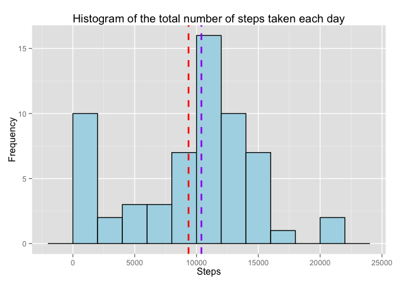

```r
g<-ggplot(activity_data_freq, aes(x=steps)) +
    geom_histogram(binwidth=2000, colour="black", fill="lightblue") +
    geom_vline(aes(xintercept=mean(steps, na.rm=T)), colour="red", linetype="dashed", size=1) +
    geom_vline(aes(xintercept=median(steps, na.rm=T)), colour="purple", linetype="dashed", size=1) +
    ggtitle("Histogram of the total number of steps taken each day") +
    scale_colour_manual("", values = c("red"="Mean", "purple"="Mendia")) +
    xlab("Steps") +
    ylab("Frequency")

    plot(g)
```

### Mean and median of the total number of steps taken per day

Calculate mean

```r
steps_mean<-mean(activity_data_freq$steps, na.rm=T)
```

The mean (red line on histogram above) is 9354.23 steps.

Calculate median

```r
steps_median<-median(activity_data_freq$steps, na.rm=T)
```

The median (purple line on histogram above) is 10395.00 steps.

### Time series plot of the 5-minute interval and the average number of steps taken, averaged across all days.

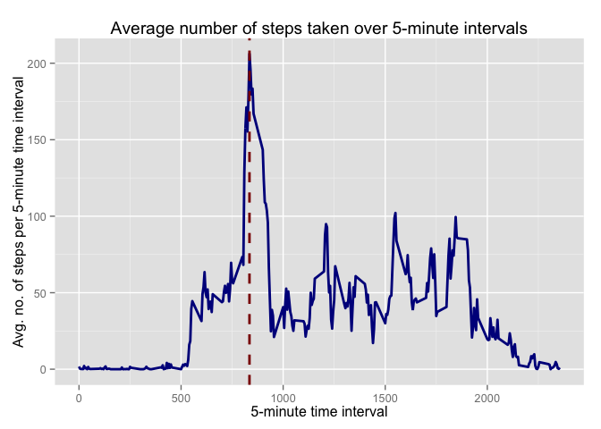

```r
activity_data_mean_date<-aggregate(x = activity_data[c("steps")],
                              FUN = mean, na.rm=TRUE,
                              by = activity_data[c("interval")])

timeseries<-filter(activity_data_mean_date,is.na(steps)==FALSE)

max_interval<-filter(timeseries,steps==max(steps))[[1]]
ggplot(timeseries, aes(interval, steps)) +
    geom_line(lwd=1, colour="darkblue") +
    xlab("5-minute time interval") +
    ylab("Avg. no. of steps per 5-minute time interval") +
    ggtitle("Average number of steps taken over 5-minute intervals") +
    geom_vline(aes(xintercept=max_interval), color="darkred", linetype="dashed", size=1)
```

#### 5-minute interval containing maximum number of steps

The 5-minute interval, on average across all the days in the dataset, with maximum number of steps (red line on time series above) is 835.00.

#### Calculate the total number of missing values in the dataset (i.e. the total number of rows with NAs)

```r
activity_data_NA<-filter(activity_data,is.na(steps)==TRUE)
NoNAs<-nrow(activity_data_NA)
```

The total number of missing values in the data column “steps” id 2304.

### Imputing missing data

In the dataset column “steps” we have missing. Therefor, we execute two different methods of data imputation: mean imputation and random sample imputation.

#### Filling in all of the missing values in the dataset by the mean for matching 5-minute interval

Perhaps the easiest way to impute is to replace each missing value with the mean of the observed values for that variable. One has to be careful, because this strategy can severely distort the distribution for this variable.

Calculating the means of 5-minute intervals

```r
activity_data_mean_date<-aggregate(x = activity_data[c("steps")],
                              FUN = mean, na.rm=TRUE,
                              by = activity_data[c("interval")])

activity_data_mean<-filter(activity_data_mean_date,is.na(steps)==FALSE)

activity_data_NA_2<-merge(activity_data,activity_data_mean,by="interval",all.x = TRUE)
activity_data_compl<-transform(activity_data_NA_2, steps.x = ifelse(is.na(steps.x), steps.y, steps.x))[(1:4)]
colnames(activity_data_compl)[2] <- "steps"
```

Aggregate data

```r
activity_data_freq_compl<-aggregate(x = activity_data_compl[c("steps")],
                                    FUN = sum, na.rm=TRUE,
                                    by = list(group.date = activity_data_compl$date))
```

Plot result of imputation

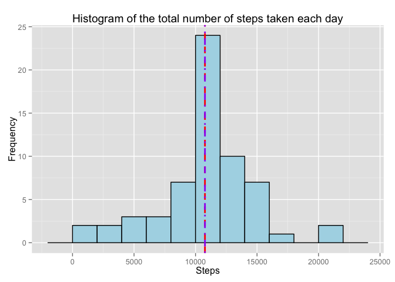

```r
ggplot(activity_data_freq_compl, aes(x=steps)) +
    geom_histogram(binwidth=2000, colour="black", fill="lightblue") +
    geom_vline(aes(xintercept=mean(steps, na.rm=T)), color="red", linetype="dashed", size=1) +
    geom_vline(aes(xintercept=median(steps, na.rm=T)), color="purple", linetype="dotdash", size=1) +
    ggtitle("Histogram of the total number of steps taken each day") +
    xlab("Steps") +
    ylab("Frequency")
```

Calculate mean

```r
steps_mean_compl<-mean(activity_data_freq_compl$steps, na.rm=T)
```

The mean is (red line on histogram above) 10766.19 steps.

Calculate median

```r
steps_median_compl<-median(activity_data_freq_compl$steps, na.rm=T)
```

The median is (purple line on histogram above) 10766.19 steps.

### Filling in all of the missing values in the dataset by the random sample from column steps

The simplest approach is to impute missing values of earnings based on the observed data for this variable. We use randomimp to create a completed data vector of the steps column by imputing random draws into the missing values of the original steps column.

Draw random samples from 5-minute interval data

```r
randomimp <- function (a){

    n<-length(a[is.na(a)])
    a[is.na(a)]<-sample(a[!is.na(a)],n,TRUE)
    return(a)

}

activity_data_sample<-randomimp(activity_data[,1])
activity_data[,1]<-activity_data_sample
```

Aggregate data

```r
activity_data_freq<-aggregate(x = activity_data[c("steps")],
                                     FUN = sum, na.rm=TRUE,
                                     by = list(group.date = activity_data$date))
```

Plot result of imputation

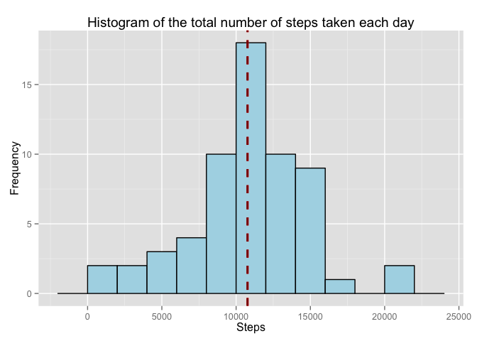

```r
ggplot(activity_data_freq, aes(x=steps)) +
    geom_histogram(binwidth=2000, colour="black", fill="lightblue") +
    geom_vline(aes(xintercept=mean(steps, na.rm=T)), color="red", linetype="dashed", size=1) +
    geom_vline(aes(xintercept=median(steps, na.rm=T)), color="darkred", linetype="dashed", size=1) +
    ggtitle("Histogram of the total number of steps taken each day") +
    xlab("Steps") +
    ylab("Frequency")
```

Calculate mean

```r
steps_mean_compl<-mean(activity_data_freq$steps, na.rm=T)
```

The mean is (red line on histogram above) 10774.93 steps.

Calculate median

```r
steps_median_compl<-median(activity_data_freq$steps, na.rm=T)
```

#### Summary data imputation

Generally the data imputation tends to bring mean and median closer together. In the case of the mean value imputation, both are identical. In the case of random sample imputation both mean and median are very close together. In both cases, however, the mean and median shift to higher values.

### Are there differences in activity patterns between weekdays and weekends?

```r
activity_data$dayofweek<-factor(weekdays(activity_data$date) %in% c('Saturday','Sunday'))
levels(activity_data$dayofweek)[levels(activity_data$dayofweek)=="TRUE"] <- "weekday"
levels(activity_data$dayofweek)[levels(activity_data$dayofweek)=="FALSE"] <- "weekend"
```

Aggregate data

```r
activity_data_mean_date<-aggregate(x = activity_data[c("steps")],
                                   FUN = mean, na.rm=TRUE,
                                   by = activity_data[c("interval","dayofweek")])
```

Plot result

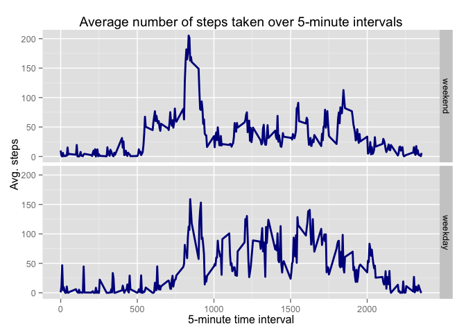

```r
ggplot(activity_data_mean_date, aes(interval, steps)) +
      geom_line(lwd=1, colour="darkblue") +
      xlab("5-minute time interval") +
      ylab("Avg. steps") +
      ggtitle("Average number of steps taken over 5-minute intervals") +
      facet_grid(dayofweek ~ .)
```

### References

1. http://www.stat.columbia.edu/~gelman/arm/missing.pdf
2. http://www.rd.dnc.ac.jp/~tunenori/doc/elml_2013_3_20_50062.pdf
3. https://class.coursera.org/repdata-012/human_grading/view/courses/973513/assessments/3/submissions